# Introduction

Lending companies work by analyzing the financial history of their loan applicants and choosing whether the applicant is too risky to be given a loan. If the applicant is not, the company then determines the terms of the loan. To acquire these applicants, companies can organically receive them through their websites/apps, often with the help of advertisement campaigns. Other times, lending companies partner with peer-to-peer (P2P) lending marketplaces, in order to acquire leads of possible applicants. Some example marketplaces include Upstart, Lending Tree and Lending Club. In this project, we are going to assess the ‘quality’ of the leads our company receives from these marketplaces.

**Market**: The target audience is the set of loan applicants who reached out through an intermediary marketplace.

**Product**: A loan.

**Goal**: Develop a model to predict for ‘quality’ applicants. In this case study, ‘quality’ applicants are those who reach a key part of the loan application process.

# Importing Essential Libraries

```python
import pandas as pd
import numpy as np
import seaborn as sns
import matplotlib.pyplot as plt
import matplotlib.colors as mcolors
import random
import time
```

```python
dataset = pd.read_csv('Financial Data.csv')
```

# Exploratory Data Analysis (EDA)

```python
dataset.head()
```

|  | entry_id | age | pay_schedule | home_owner | income | months_employed | years_employed | current_address_year | personal_account_m | personal_account_y | ... | amount_requested | risk_score | risk_score_2 | risk_score_3 | risk_score_4 | risk_score_5 | ext_quality_score | ext_quality_score_2 | inquiries_last_month | e_signed |
| --- | --- | --- | --- | --- | --- | --- | --- | --- | --- | --- | --- | --- | --- | --- | --- | --- | --- | --- | --- | --- | --- |
| 0 | 7629673 | 40 | bi-weekly | 1 | 3135 | 0 | 3 | 3 | 6 | 2 | ... | 550 | 36200 | 0.737398 | 0.903517 | 0.487712 | 0.515977 | 0.580918 | 0.380918 | 10 | 1 |
| 1 | 3560428 | 61 | weekly | 0 | 3180 | 0 | 6 | 3 | 2 | 7 | ... | 600 | 30150 | 0.738510 | 0.881027 | 0.713423 | 0.826402 | 0.730720 | 0.630720 | 9 | 0 |
| 2 | 6934997 | 23 | weekly | 0 | 1540 | 6 | 0 | 0 | 7 | 1 | ... | 450 | 34550 | 0.642993 | 0.766554 | 0.595018 | 0.762284 | 0.531712 | 0.531712 | 7 | 0 |
| 3 | 5682812 | 40 | bi-weekly | 0 | 5230 | 0 | 6 | 1 | 2 | 7 | ... | 700 | 42150 | 0.665224 | 0.960832 | 0.767828 | 0.778831 | 0.792552 | 0.592552 | 8 | 1 |
| 4 | 5335819 | 33 | semi-monthly | 0 | 3590 | 0 | 5 | 2 | 2 | 8 | ... | 1100 | 53850 | 0.617361 | 0.857560 | 0.613487 | 0.665523 | 0.744634 | 0.744634 | 12 | 0 |

5 rows × 21 columns

```python
dataset.columns
```

```
Index(['entry_id', 'age', 'pay_schedule', 'home_owner', 'income',
       'months_employed', 'years_employed', 'current_address_year',
       'personal_account_m', 'personal_account_y', 'has_debt',
       'amount_requested', 'risk_score', 'risk_score_2', 'risk_score_3',
       'risk_score_4', 'risk_score_5', 'ext_quality_score',
       'ext_quality_score_2', 'inquiries_last_month', 'e_signed'],
      dtype='object')
```

```python
dataset.describe()
```

|  | entry_id | age | home_owner | income | months_employed | years_employed | current_address_year | personal_account_m | personal_account_y | has_debt | amount_requested | risk_score | risk_score_2 | risk_score_3 | risk_score_4 | risk_score_5 | ext_quality_score | ext_quality_score_2 | inquiries_last_month | e_signed |
| --- | --- | --- | --- | --- | --- | --- | --- | --- | --- | --- | --- | --- | --- | --- | --- | --- | --- | --- | --- | --- |
| count | 1.790800e+04 | 17908.000000 | 17908.000000 | 17908.000000 | 17908.000000 | 17908.000000 | 17908.000000 | 17908.000000 | 17908.000000 | 17908.000000 | 17908.000000 | 17908.000000 | 17908.000000 | 17908.000000 | 17908.000000 | 17908.000000 | 17908.000000 | 17908.000000 | 17908.000000 | 17908.000000 |
| mean | 5.596978e+06 | 43.015412 | 0.425173 | 3657.214653 | 1.186006 | 3.526860 | 3.584711 | 3.427183 | 3.503350 | 0.795399 | 950.446449 | 61086.302211 | 0.690878 | 0.878276 | 0.583155 | 0.718252 | 0.623112 | 0.622068 | 6.457226 | 0.538251 |
| std | 2.562473e+06 | 11.873107 | 0.494383 | 1504.890063 | 2.400897 | 2.259732 | 2.751937 | 2.216440 | 1.955568 | 0.403421 | 698.543683 | 15394.255020 | 0.090470 | 0.054563 | 0.125061 | 0.120697 | 0.139729 | 0.139898 | 3.673093 | 0.498549 |
| min | 1.111398e+06 | 18.000000 | 0.000000 | 905.000000 | 0.000000 | 0.000000 | 0.000000 | 0.000000 | 0.000000 | 0.000000 | 350.000000 | 2100.000000 | 0.023258 | 0.451371 | 0.016724 | 0.153367 | 0.010184 | 0.006622 | 1.000000 | 0.000000 |
| 25% | 3.378999e+06 | 34.000000 | 0.000000 | 2580.000000 | 0.000000 | 2.000000 | 2.000000 | 2.000000 | 2.000000 | 1.000000 | 600.000000 | 49350.000000 | 0.640993 | 0.850882 | 0.500208 | 0.633708 | 0.521735 | 0.519677 | 4.000000 | 0.000000 |
| 50% | 5.608376e+06 | 42.000000 | 0.000000 | 3260.000000 | 0.000000 | 3.000000 | 3.000000 | 2.000000 | 3.000000 | 1.000000 | 700.000000 | 61200.000000 | 0.699561 | 0.881004 | 0.588208 | 0.725113 | 0.625944 | 0.622974 | 6.000000 | 1.000000 |
| 75% | 7.805624e+06 | 51.000000 | 1.000000 | 4670.000000 | 1.000000 | 5.000000 | 5.000000 | 5.000000 | 4.000000 | 1.000000 | 1100.000000 | 72750.000000 | 0.752887 | 0.912608 | 0.672395 | 0.806681 | 0.729841 | 0.728940 | 8.000000 | 1.000000 |
| max | 9.999874e+06 | 96.000000 | 1.000000 | 9985.000000 | 11.000000 | 16.000000 | 12.000000 | 11.000000 | 15.000000 | 1.000000 | 10200.000000 | 99750.000000 | 0.999997 | 0.999024 | 0.978932 | 0.996260 | 0.970249 | 0.966953 | 30.000000 | 1.000000 |

```python
dataset.isnull().sum()
```

```
entry_id                0
age                     0
pay_schedule            0
home_owner              0
income                  0
months_employed         0
years_employed          0
current_address_year    0
personal_account_m      0
personal_account_y      0
has_debt                0
amount_requested        0
risk_score              0
risk_score_2            0
risk_score_3            0
risk_score_4            0
risk_score_5            0
ext_quality_score       0
ext_quality_score_2     0
inquiries_last_month    0
e_signed                0
dtype: int64
```

### NOTE that the data is already cleaned because these set of people who are users coming from an intermediary market place. So any data that is missing or is not to be used is probably cleaned before it reaches to us. So we can have very good expectations that the data we are getting from the P2P market place is cleaned and saves us from Data Cleaning. 😃

```python
dataset2 = dataset.drop(columns = ['entry_id', 'pay_schedule', 'e_signed'])
```

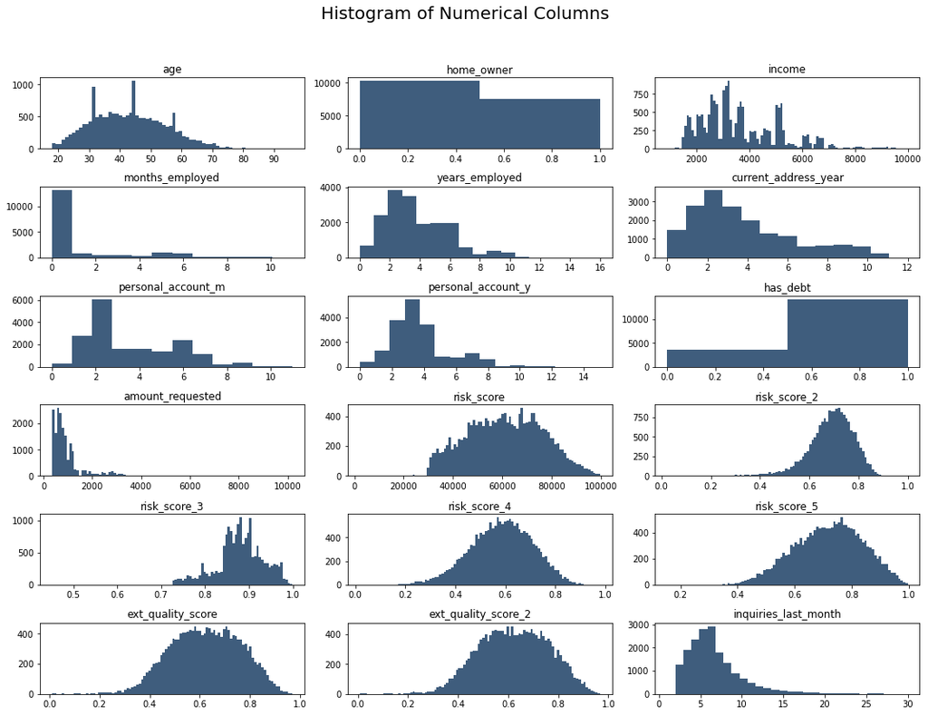

```python
fig = plt.figure(figsize = (15, 12))
plt.suptitle('Histogram of Numerical Columns', fontsize = 20)
for i in range(dataset2.shape[1]):
    plt.subplot(6, 3, i + 1)
    f = plt.gca()
    f.set_title(dataset2.columns.values[i])

    vals = np.size(dataset2.iloc[:, i].unique())
    if vals >= 100:
        vals = 100

    plt.hist(dataset2.iloc[:, i], bins = vals, color = '#3F5D7D')
plt.tight_layout(rect = [0, 0.03, 1, 0.95])
#plt.savefig('1.Histogram of Numerical Columns.png')
```

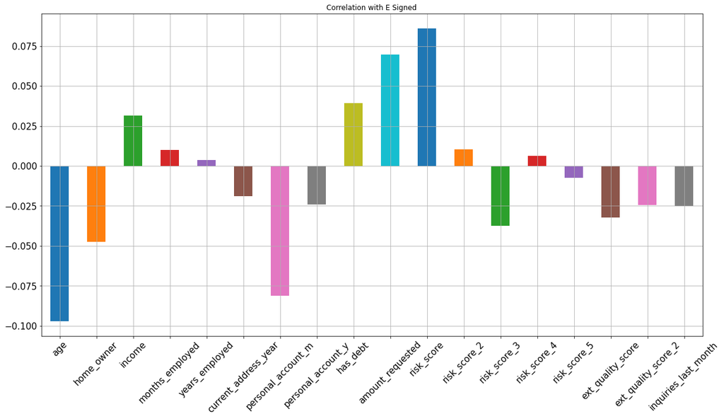

```python
dataset2.corrwith(dataset.e_signed).plot.bar(figsize = (20, 10), title = "Correlation with E Signed",
                                          fontsize = 15, rot = 45, grid = True, color = mcolors.TABLEAU_COLORS)
#plt.savefig('2.Correlation of Features with the Response Variable.png')
```

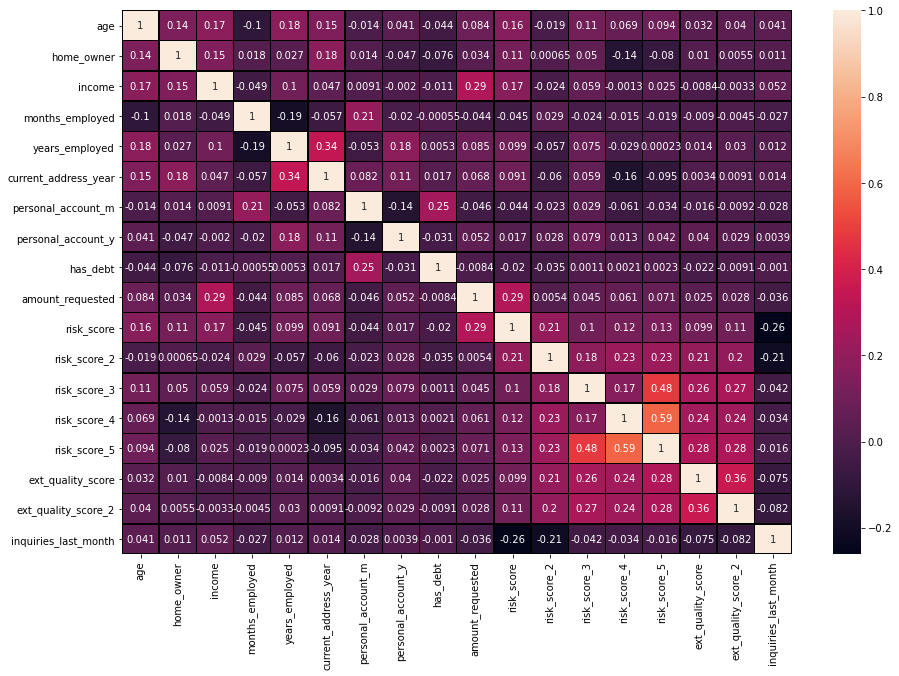

```python
f, ax = plt.subplots(figsize = (15, 10))
sns.heatmap(dataset2.corr(), annot = True, linewidths = 0.5, linecolor = 'black')
#plt.savefig('3.Heatmap showing Correlation of all the Features.png')
```

# Data Preprocessing

```python
#random.seed(100)
dataset = dataset.drop(columns = ['months_employed'])
dataset['personal_account_months'] = (dataset.personal_account_m + (dataset.personal_account_y * 12))
dataset = dataset.drop(columns = ['personal_account_m', 'personal_account_y'])
```

```python
dataset.head()
```

|  | entry_id | age | pay_schedule | home_owner | income | years_employed | current_address_year | has_debt | amount_requested | risk_score | risk_score_2 | risk_score_3 | risk_score_4 | risk_score_5 | ext_quality_score | ext_quality_score_2 | inquiries_last_month | e_signed | personal_account_months |
| --- | --- | --- | --- | --- | --- | --- | --- | --- | --- | --- | --- | --- | --- | --- | --- | --- | --- | --- | --- |
| 0 | 7629673 | 40 | bi-weekly | 1 | 3135 | 3 | 3 | 1 | 550 | 36200 | 0.737398 | 0.903517 | 0.487712 | 0.515977 | 0.580918 | 0.380918 | 10 | 1 | 30 |
| 1 | 3560428 | 61 | weekly | 0 | 3180 | 6 | 3 | 1 | 600 | 30150 | 0.738510 | 0.881027 | 0.713423 | 0.826402 | 0.730720 | 0.630720 | 9 | 0 | 86 |
| 2 | 6934997 | 23 | weekly | 0 | 1540 | 0 | 0 | 1 | 450 | 34550 | 0.642993 | 0.766554 | 0.595018 | 0.762284 | 0.531712 | 0.531712 | 7 | 0 | 19 |
| 3 | 5682812 | 40 | bi-weekly | 0 | 5230 | 6 | 1 | 1 | 700 | 42150 | 0.665224 | 0.960832 | 0.767828 | 0.778831 | 0.792552 | 0.592552 | 8 | 1 | 86 |
| 4 | 5335819 | 33 | semi-monthly | 0 | 3590 | 5 | 2 | 1 | 1100 | 53850 | 0.617361 | 0.857560 | 0.613487 | 0.665523 | 0.744634 | 0.744634 | 12 | 0 | 98 |

```python
dataset.dtypes
```

```
entry_id                     int64
age                          int64
pay_schedule                object
home_owner                   int64
income                       int64
years_employed               int64
current_address_year         int64
has_debt                     int64
amount_requested             int64
risk_score                   int64
risk_score_2               float64
risk_score_3               float64
risk_score_4               float64
risk_score_5               float64
ext_quality_score          float64
ext_quality_score_2        float64
inquiries_last_month         int64
e_signed                     int64
personal_account_months      int64
dtype: object
```

## One-Hot Encoding

```python
dataset = pd.get_dummies(dataset)
dataset.columns
```

```
Index(['entry_id', 'age', 'home_owner', 'income', 'years_employed',
       'current_address_year', 'has_debt', 'amount_requested', 'risk_score',
       'risk_score_2', 'risk_score_3', 'risk_score_4', 'risk_score_5',
       'ext_quality_score', 'ext_quality_score_2', 'inquiries_last_month',
       'e_signed', 'personal_account_months', 'pay_schedule_bi-weekly',
       'pay_schedule_monthly', 'pay_schedule_semi-monthly',
       'pay_schedule_weekly'],
      dtype='object')
```

```python
dataset = dataset.drop(columns = ['pay_schedule_semi-monthly'])
```

## Removing Extra Columns

```python
y = dataset['e_signed']
users = dataset['entry_id']
dataset = dataset.drop(columns = ['e_signed', 'entry_id'])
```

## Splitting into Train & Test Set

```python
from sklearn.model_selection import train_test_split
X_train, X_test, y_train, y_test = train_test_split(dataset, y, test_size = 0.2, random_state = 0)
```

## Feature Scaling

```python
from sklearn.preprocessing import StandardScaler
sc = StandardScaler()
X_train2 = pd.DataFrame(sc.fit_transform(X_train))
X_test2 = pd.DataFrame(sc.transform(X_test))

X_train2.columns = X_train.columns.values
X_test2.columns = X_test.columns.values

X_train2.index = X_train.index.values
X_test2.index = X_test.index.values

X_train = X_train2
X_test = X_test2
```

## Model Building

### Logistic Regression

```python
from sklearn.linear_model import LogisticRegression
classifier = LogisticRegression(random_state = 0, solver = 'liblinear', penalty = 'l1')
classifier.fit(X_train, y_train)


# Predicitng the Test Set
y_pred = classifier.predict(X_test)


# Checking Acccuracy
from sklearn.metrics import confusion_matrix, classification_report, accuracy_score, precision_score, recall_score, f1_score
acc = (accuracy_score(y_test, y_pred))
print(acc)
print(classification_report(y_test, y_pred))
```

```
0.5619765494137353
              precision    recall  f1-score   support

           0       0.53      0.39      0.45      1654
           1       0.58      0.71      0.63      1928

    accuracy                           0.56      3582
   macro avg       0.56      0.55      0.54      3582
weighted avg       0.56      0.56      0.55      3582
```

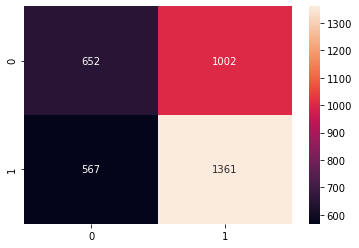

```python
cm = confusion_matrix(y_test, y_pred)
sns.heatmap(cm, annot = True, fmt = 'g')
#plt.savefig('4.Logistic Regression - Confusion Matrix.png')
```

```python
prec = precision_score(y_test, y_pred)
rec = recall_score(y_test, y_pred)
f1 = f1_score(y_test, y_pred)

results = pd.DataFrame([['Linear Regression (Lasso)', acc, prec, rec, f1]],
             columns = ['Model', 'Accuracy', 'Precision', 'Recall', 'F1 Score'])
```

### Support Vector Classification SVC

```python
from sklearn.svm import SVC
classifier = SVC(random_state = 0, kernel = 'rbf')
classifier.fit(X_train, y_train)


# Predicitng the Test Set
y_pred = classifier.predict(X_test)


# Checking Acccuracy
acc = (accuracy_score(y_test, y_pred))
print(acc)
print(classification_report(y_test, y_pred))
```

```
0.5915689558905639
              precision    recall  f1-score   support

           0       0.57      0.48      0.52      1654
           1       0.61      0.69      0.65      1928

    accuracy                           0.59      3582
   macro avg       0.59      0.58      0.58      3582
weighted avg       0.59      0.59      0.59      3582
```

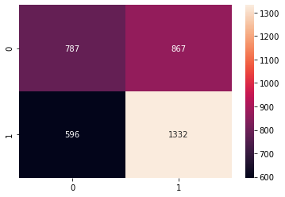

```python
cm = confusion_matrix(y_test, y_pred)
sns.heatmap(cm, annot = True, fmt = 'g')
#plt.savefig('5.Support Vector Classification - Confusion Matrix.png')
```

```python
prec = precision_score(y_test, y_pred)
rec = recall_score(y_test, y_pred)
f1 = f1_score(y_test, y_pred)

model_results = pd.DataFrame([['SVC (RBF)', acc, prec, rec, f1]],
             columns = ['Model', 'Accuracy', 'Precision', 'Recall', 'F1 Score'])
results = results.append(model_results, ignore_index = True)
```

### Random Forest Classifier

```python
from sklearn.ensemble import RandomForestClassifier
classifier = RandomForestClassifier(random_state = 0, n_estimators = 100, criterion = 'entropy')
classifier.fit(X_train, y_train)


# Predicitng the Test Set
y_pred = classifier.predict(X_test)


# Checking Acccuracy
acc = (accuracy_score(y_test, y_pred))
print(acc)
print(classification_report(y_test, y_pred))
```

```
0.6217197096594081
              precision    recall  f1-score   support

           0       0.60      0.56      0.58      1654
           1       0.64      0.68      0.66      1928

    accuracy                           0.62      3582
   macro avg       0.62      0.62      0.62      3582
weighted avg       0.62      0.62      0.62      3582
```

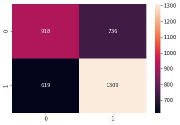

```python
cm = confusion_matrix(y_test, y_pred)
sns.heatmap(cm, annot = True, fmt = 'g')
#plt.savefig('6.Random Forest Classifier - Confusion Matrix.png')
```

```python
prec = precision_score(y_test, y_pred)
rec = recall_score(y_test, y_pred)
f1 = f1_score(y_test, y_pred)

model_results = pd.DataFrame([['Random Forest (n = 100)', acc, prec, rec, f1]],
             columns = ['Model', 'Accuracy', 'Precision', 'Recall', 'F1 Score'])
results = results.append(model_results, ignore_index = True)
```

```python
results
```

|  | Model | Accuracy | Precision | Recall | F1 Score |
| --- | --- | --- | --- | --- | --- |
| 0 | Linear Regression (Lasso) | 0.561977 | 0.575963 | 0.705913 | 0.634351 |
| 1 | SVC (RBF) | 0.591569 | 0.605730 | 0.690871 | 0.645505 |
| 2 | Random Forest (n = 100) | 0.621720 | 0.640098 | 0.678942 | 0.658948 |

### K-Fold Cross Validation for our Random Forest Algorithm

```python
from sklearn.model_selection import cross_val_score
accuracies = cross_val_score(estimator = classifier, X = X_train, y = y_train, cv = 10)
print("Random Forest Classifier Mean Accuracy: %0.2f" % accuracies.mean())
print("Random Forest Classifier Standard Deviation: %0.2f" % (accuracies.std() * 2))
```

```
Random Forest Classifier Mean Accuracy: 0.63
Random Forest Classifier Standard Deviation: 0.03
```

## Parameter Tuning of Random Forest Algorithm

```python
parameters = {'max_depth': [3, None], 'max_features': [1, 5, 10], 'min_samples_split': [2, 5, 10],
              'min_samples_leaf': [1, 5, 10], 'bootstrap': [True, False], 'criterion': ['entropy', 'gini']}
```

```python
from sklearn.model_selection import GridSearchCV
grid_search = GridSearchCV(estimator = classifier, param_grid = parameters, scoring = 'accuracy', cv = 10, n_jobs = -1)

t0 = time.time()
grid_search = grid_search.fit(X_train, y_train)
t1 = time.time()
print('Took %0.2f Seconds' % (t1 - t0))
```

```
Took 3986.89 Seconds
```

```python
rf_best_accuracy = grid_search.best_score_
rf_best_parameters = grid_search.best_params_
rf_best_accuracy, rf_best_parameters
```

```
(0.6353512282315882,
 {'bootstrap': True,
  'criterion': 'gini',
  'max_depth': None,
  'max_features': 10,
  'min_samples_leaf': 5,
  'min_samples_split': 2})
```

#### Parameter Tuning has not given much of an improvement but maybe by a few points.

```python
y_pred = grid_search.predict(X_test)


# Checking Acccuracy
acc = (accuracy_score(y_test, y_pred))
print(acc)
print(classification_report(y_test, y_pred))
```

```
0.6395868230039085
              precision    recall  f1-score   support

           0       0.62      0.57      0.59      1654
           1       0.65      0.70      0.68      1928

    accuracy                           0.64      3582
   macro avg       0.64      0.63      0.63      3582
weighted avg       0.64      0.64      0.64      3582
```

```python
prec = precision_score(y_test, y_pred)
rec = recall_score(y_test, y_pred)
f1 = f1_score(y_test, y_pred)

model_results = pd.DataFrame([['Random Forest (Grid Search)', acc, prec, rec, f1]],
             columns = ['Model', 'Accuracy', 'Precision', 'Recall', 'F1 Score'])
results = results.append(model_results, ignore_index = True)
```

```python
results
```

|  | Model | Accuracy | Precision | Recall | F1 Score |
| --- | --- | --- | --- | --- | --- |
| 0 | Linear Regression (Lasso) | 0.561977 | 0.575963 | 0.705913 | 0.634351 |
| 1 | SVC (RBF) | 0.591569 | 0.605730 | 0.690871 | 0.645505 |
| 2 | Random Forest (n = 100) | 0.621720 | 0.640098 | 0.678942 | 0.658948 |
| 3 | Random Forest (Grid Search) | 0.639587 | 0.653494 | 0.703320 | 0.677492 |

# Final Result

```python
final_results = pd.concat([y_test, users], axis = 1).dropna()
final_results['predictions'] = y_pred
final_results = final_results[['entry_id', 'e_signed', 'predictions']]
```

```python
final_results
```

|  | entry_id | e_signed | predictions |
| --- | --- | --- | --- |
| 8 | 6493191 | 1.0 | 0 |
| 9 | 8908605 | 1.0 | 0 |
| 12 | 6889184 | 1.0 | 1 |
| 16 | 9375601 | 0.0 | 1 |
| 18 | 8515555 | 1.0 | 1 |
| ... | ... | ... | ... |
| 17881 | 5028251 | 1.0 | 1 |
| 17888 | 8958068 | 0.0 | 0 |
| 17890 | 3605941 | 0.0 | 1 |
| 17901 | 1807355 | 0.0 | 1 |
| 17907 | 1498559 | 1.0 | 1 |

3582 rows × 3 columns

# Conclusion

Our model has given us an accuracy of around 64%. With this, we have an algorithm that can help predict whether a user will complete the E-Signing step of the loan application. One way to leverage this model is to target those predicted to not reach the e-sign phase with customized onboarding. This means that when a lead arrives from the marketplace, they may receive a different onboarding experience based on how likely they are to finish the general onboarding process. This can help our company minimize how many people drop off from the funnel. This funnel of screens is as effective as we, as a company, build it. Therefore, user drop-off in this funnel falls entirely on our shoulders. So, with new onboarding screens built intentionally to lead users to finalize the loan application, we can attempt to get more than 40% of those predicted to not finish the process to complete the e-sign step. If we can do this, then we can drastically increase profits. Many lending companies provide hundreds of loans every day, gaining money for each one. As a result, if we can increase the number of loan takers, we are increasing profits. All with a simple model!